# Project 4 - Accuracy and Beyond

Dhairav Chhatbar

6/27/2020

The goal of this assignment is give you practice working with accuracy and other recommender system metrics

- As in your previous assignments, compare the accuracy of at least two recommender system algorithms against your offline data
- Implement support for at least one business or user experience goal such as increased serendipity, novelty, or diversity
- Compare and report on any change in accuracy before and after you’ve made the change in #2
- As part of your textual conclusion, discuss one or more additional experiments that could be performed and/or metrics that could be evaluated only if online evaluation was possible. Also, briefly propose how you would design a reasonable online evaluation environment

### Load Data & Goals

In this assignment we will attempt the best recommender model on the Jester dataset which is a a rating of a set of jokes

```r
library(ggplot2)
library(recommenderlab)
library(dplyr)
library(kableExtra)
data("Jester5k")
```

### Explore Data

Exploratory visuals show that this dataset has:

```r
dim(Jester5k)
```

```
## [1] 5000  100
```

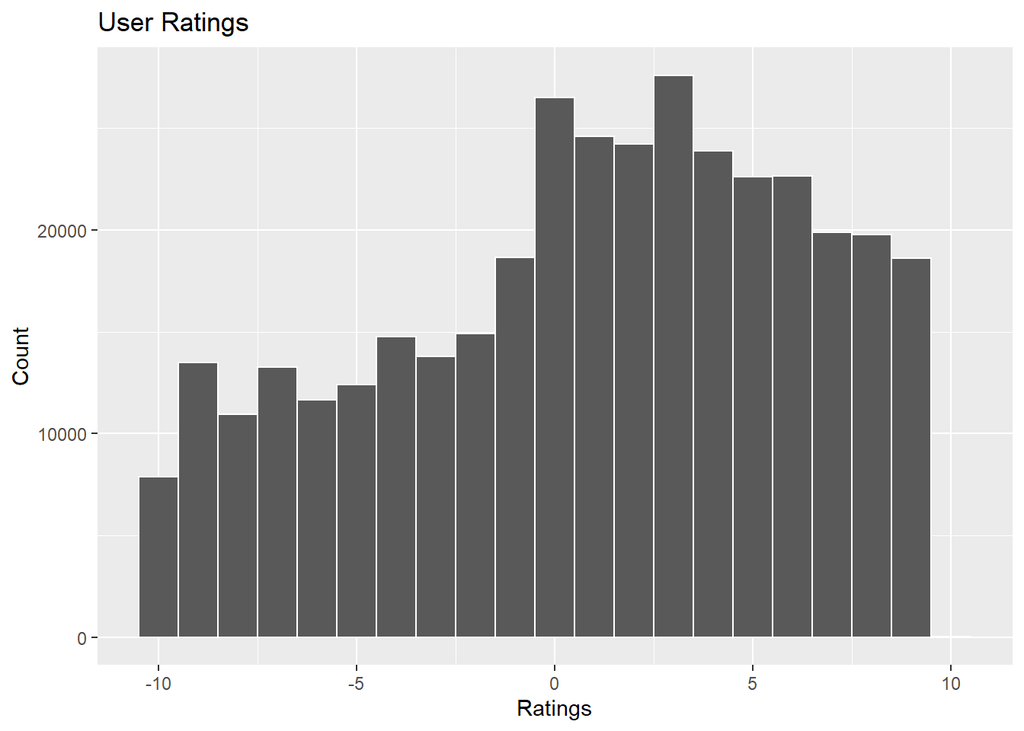

```r
# Ratings
all_ratings <- getRatings(Jester5k)
ggplot() + geom_histogram(aes(all_ratings), binwidth = 1, col="white") + labs(title = "User Ratings", x="Ratings", y="Count")
```

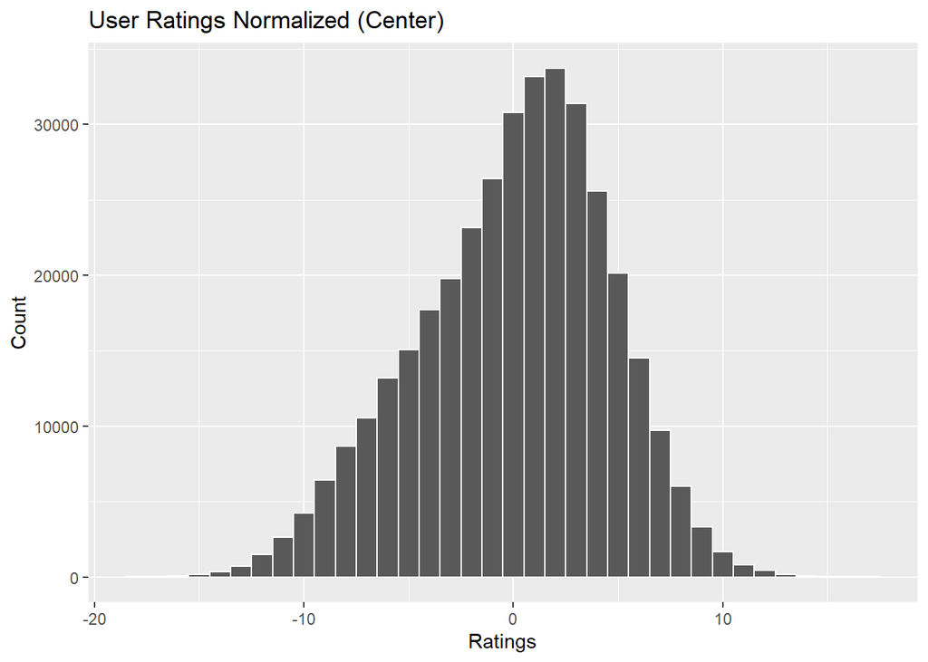

```r
all_ratings_norm <- getRatings(normalize(Jester5k, "Center"))
ggplot() + geom_histogram(aes(all_ratings_norm), binwidth = 1, col="white") + labs(title = "User Ratings Normalized (Center)", x="Ratings", y="Count")
```

```r
summary(all_ratings_norm)
```

```
##     Min.  1st Qu.   Median     Mean  3rd Qu.     Max.
## -18.2616  -3.0169   0.4904   0.0000   3.2279  17.4594
```

```r
#Users
mean(rowCounts(Jester5k))
```

```
## [1] 72.4212
```

[figure not shown]

```r
users <- rowCounts(Jester5k)
ggplot() + geom_histogram(aes(users), binwidth = 5, col="white") + labs(title = "User Ratings Normalized (Center)", x="Jokes Rated", y="Number of Users")
```

```r
#Density
sum(users)/(dim(Jester5k)[1]*dim(Jester5k)[2])
```

```
## [1] 0.724212
```

#### Need to Remove

```r
Jester_Norm <-normalize(Jester5k, "Center")


eval_jokes <- evaluationScheme(data=Jester_Norm, method="split", train=.80,
                               given=min(rowCounts(Jester_Norm))-3, goodRating = 5)
Jokes_rec_IBCF <- Recommender(data = getData(eval_jokes, "train"), method = "IBCF")
Jokes_pred_IBCF <- predict(Jokes_rec_IBCF, newdata = getData(eval_jokes, "known"), type="ratings", n=5)

calcPredictionAccuracy(Jokes_pred_IBCF, data = getData(eval_jokes, "unknown"))
```

```
##      RMSE       MSE       MAE
##  4.870178 23.718635  3.870276
```

```r
head(getConfusionMatrix(evaluate(eval_jokes, method = "IBCF", n = seq(10, 100, 10))))
```

```
## IBCF run fold/sample [model time/prediction time]
##   1
```

```
## [0.26sec/0.15sec]
```

```
## [[1]]
##        TP     FP    FN     TN  precision    recall       TPR       FPR
## 10  0.602  9.398 4.434 52.566 0.06020000 0.1160706 0.1160706 0.1519150
## 20  1.354 18.646 3.682 43.318 0.06770000 0.2684553 0.2684553 0.3010942
## 30  2.218 27.782 2.818 34.182 0.07393333 0.4488684 0.4488684 0.4485567
## 40  3.065 36.935 1.971 25.029 0.07662500 0.6250577 0.6250577 0.5962062
## 50  3.908 46.092 1.128 15.872 0.07816000 0.7835856 0.7835856 0.7437124
## 60  4.633 55.367 0.403  6.597 0.07721667 0.9265112 0.9265112 0.8933661
## 70  5.036 61.963 0.000  0.001 0.07516644 1.0000000 1.0000000 0.9999825
## 80  5.036 61.963 0.000  0.001 0.07516644 1.0000000 1.0000000 0.9999825
## 90  5.036 61.963 0.000  0.001 0.07516644 1.0000000 1.0000000 0.9999825
## 100 5.036 61.963 0.000  0.001 0.07516644 1.0000000 1.0000000 0.9999825
```

#### Build Models

```r
eval_jokes <- evaluationScheme(data=Jester5k, method="split", train=.80,
                               given=min(rowCounts(Jester_Norm))-3, goodRating = 5)
num_jokes_to_recommend <- 100

recc_algos <- list(
  IBCF_C = list(name = "IBCF", param = list(method = "Cosine", normalize = "Center")),
  IBCF_P = list(name = "IBCF", param = list(method = "Pearson", normalize = "Center")),
  UBCF_C = list(name = "UBCF", param = list(method = "Cosine", normalize = "Center")),
  UBCF_P = list(name = "UBCF", param = list(method = "Pearson", normalize = "Center")),
  m_SVD = list(name = "SVD", param = list( k=5, normalize = "Center")),
  random = list(name = "RANDOM", param=NULL)
)

recommendation_results <- evaluate(eval_jokes, method = recc_algos, n = c(1,5, seq(10, num_jokes_to_recommend, 10)))
```

```
## IBCF run fold/sample [model time/prediction time]
##   1  [0.26sec/0.21sec]
## IBCF run fold/sample [model time/prediction time]
##   1  [0.34sec/0.32sec]
## UBCF run fold/sample [model time/prediction time]
##   1  [0.02sec/5.35sec]
## UBCF run fold/sample [model time/prediction time]
##   1  [0.04sec/4.77sec]
## SVD run fold/sample [model time/prediction time]
##   1  [0.09sec/0.14sec]
## RANDOM run fold/sample [model time/prediction time]
##   1  [0sec/0.31sec]
```

#### Acucracy and ROC

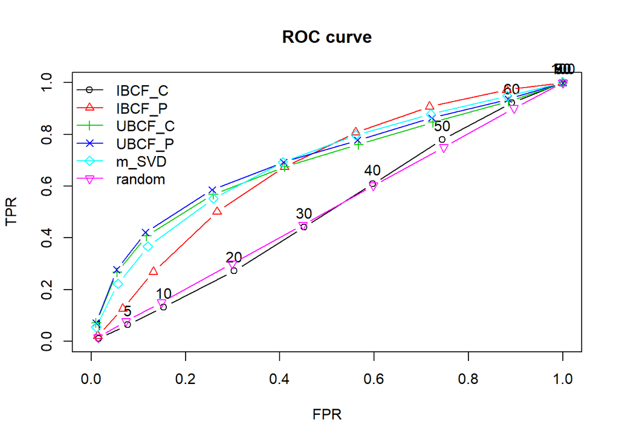

```r
plot(recommendation_results, annotate = TRUE, legend = "topleft")
title("ROC curve")
```

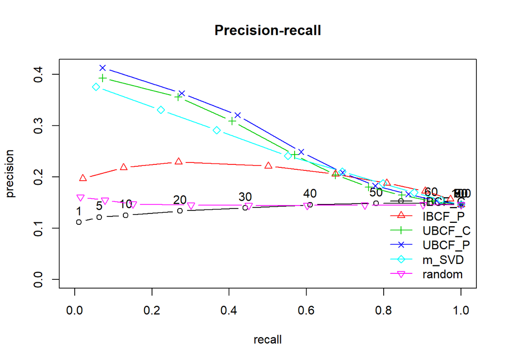

```r
plot(recommendation_results, "prec/rec", annotate = TRUE, legend = "bottomright")
title("Precision-recall")
```

### Parameter Optimization

```r
vector_k <- c(5, 10, 20, 30, 40)
models_to_evaluate <- lapply(vector_k, function(k){
  list(name = "SVD", param = list(normalize = "Center", k = k))
})
names(models_to_evaluate) <- paste0("IBCF_k_", vector_k)

n_recommendations <- c(1, 5, seq(10, 100, 10))
list_results <- evaluate(x = eval_jokes, method = models_to_evaluate, n = n_recommendations)
```

```
## SVD run fold/sample [model time/prediction time]
##   1  [0.09sec/0.14sec]
## SVD run fold/sample [model time/prediction time]
##   1  [0.11sec/0.31sec]
## SVD run fold/sample [model time/prediction time]
##   1  [0.14sec/0.16sec]
## SVD run fold/sample [model time/prediction time]
##   1  [0.27sec/0.12sec]
## SVD run fold/sample [model time/prediction time]
##   1  [0.32sec/0.15sec]
```

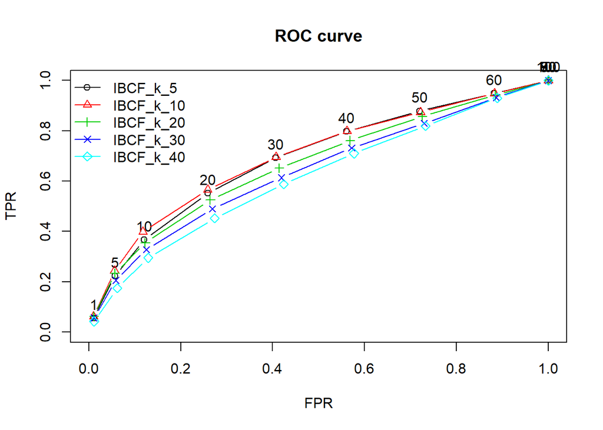

```r
plot(list_results, annotate = 1, legend = "topleft")
title("ROC curve")
```

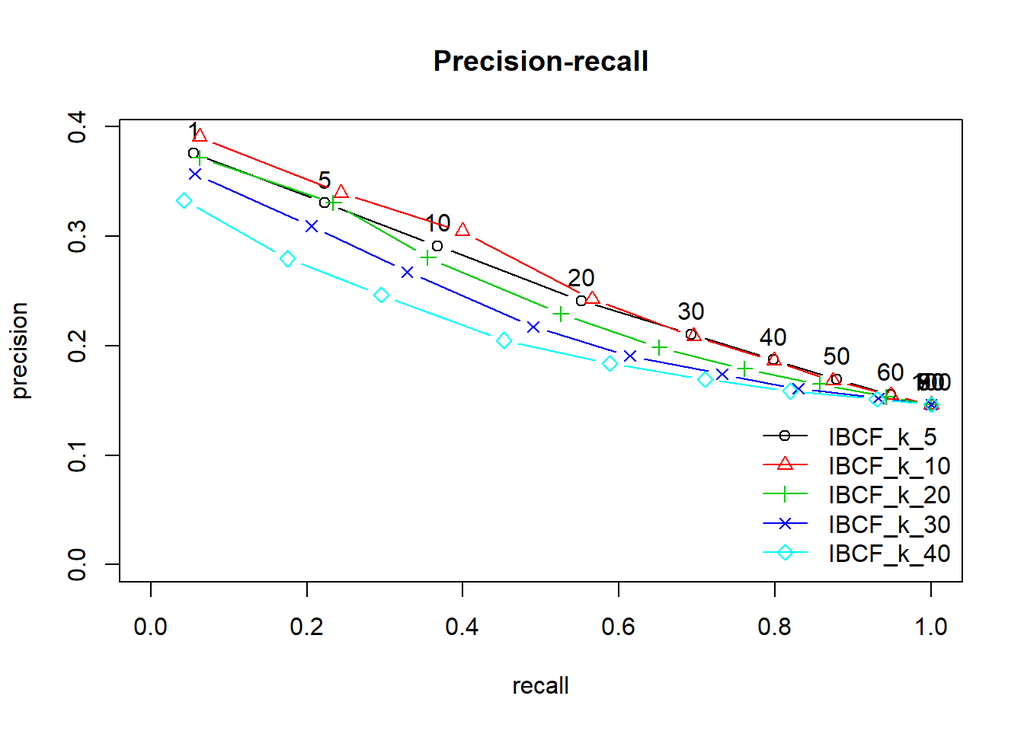

```r
plot(list_results, "prec/rec", annotate = 1, legend = "bottomright")
title("Precision-recall")
```